# Pràctica 2. Tractament del dataset red wine quality

Josep Pou Mas - Xavier Badia Mulero

## 1-2. Descripció del dataset

Llegim el fitxer de dades que conté tota la informació dels vins

```r
# Seleccionem el directori on es troba els documents
setwd("/Pràctica_2")

# Llegim el dataset
data_wine <- read.csv('winequality-red.csv', header = TRUE, sep = ",")
```

Visualitzem els sis primers registres del dataframe que presenta les dades del dataset d’entrada amb la informació.

```r
head(data_wine)
```

```
##   fixed.acidity volatile.acidity citric.acid residual.sugar chlorides
## 1           7.4             0.70        0.00            1.9     0.076
## 2           7.8             0.88        0.00            2.6     0.098
## 3           7.8             0.76        0.04            2.3     0.092
## 4          11.2             0.28        0.56            1.9     0.075
## 5           7.4             0.70        0.00            1.9     0.076
## 6           7.4             0.66        0.00            1.8     0.075
##   free.sulfur.dioxide total.sulfur.dioxide density   pH sulphates alcohol
## 1                  11                   34  0.9978 3.51      0.56     9.4
## 2                  25                   67  0.9968 3.20      0.68     9.8
## 3                  15                   54  0.9970 3.26      0.65     9.8
## 4                  17                   60  0.9980 3.16      0.58     9.8
## 5                  11                   34  0.9978 3.51      0.56     9.4
## 6                  13                   40  0.9978 3.51      0.56     9.4
##   quality
## 1       5
## 2       5
## 3       5
## 4       6
## 5       5
## 6       5
```

Consultem el nombre de registres i columnes que formen el dataset.

```r
# Obtenim el total de resgistres i variables
 dim(data_wine)
```

```
## [1] 1599   12
```

## 3. Neteja de dades

### 3.1. Elements buits i zeros

```r
# Nombre total de valors desconeguts de les variables
sapply(data_wine, function(x) sum(is.na(x)))
```

```
##        fixed.acidity     volatile.acidity          citric.acid
##                    0                    0                    0
##       residual.sugar            chlorides  free.sulfur.dioxide
##                    0                    0                    0
## total.sulfur.dioxide              density                   pH
##                    0                    0                    0
##            sulphates              alcohol              quality
##                    0                    0                    0
```

```r
# Nombre total de valors 0 de les variables
sapply(data_wine, function(x) sum(x == 0))
```

```
##        fixed.acidity     volatile.acidity          citric.acid
##                    0                    0                  132
##       residual.sugar            chlorides  free.sulfur.dioxide
##                    0                    0                    0
## total.sulfur.dioxide              density                   pH
##                    0                    0                    0
##            sulphates              alcohol              quality
##                    0                    0                    0
```

### 3.2. Identificació i tractament de valors extrems

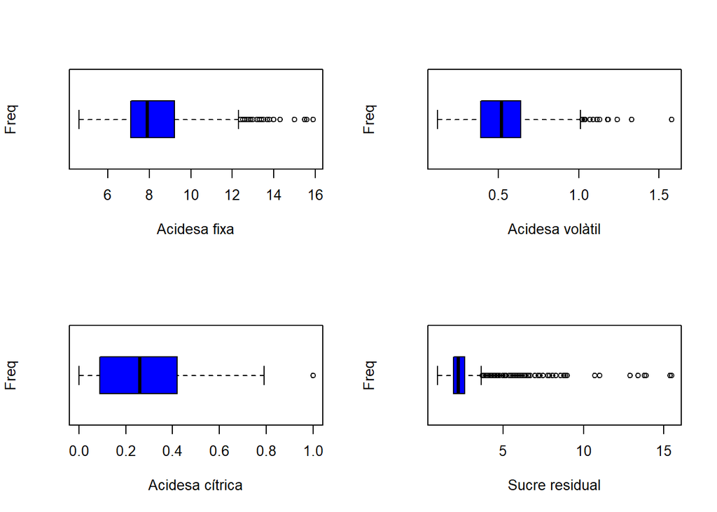

```r
par(mfrow=c(2,2))

boxplot(data_wine$fixed.acidity, xlab="Acidesa fixa", col="blue", horizontal = TRUE, ylab = "Freq")
boxplot(data_wine$volatile.acidity, xlab="Acidesa volàtil", col="blue", horizontal = TRUE, ylab = "Freq")
boxplot(data_wine$citric.acid, xlab="Acidesa cítrica", col="blue", horizontal = TRUE, ylab = "Freq")
boxplot(data_wine$residual.sugar, xlab="Sucre residual", col="blue", horizontal = TRUE, ylab = "Freq")
```

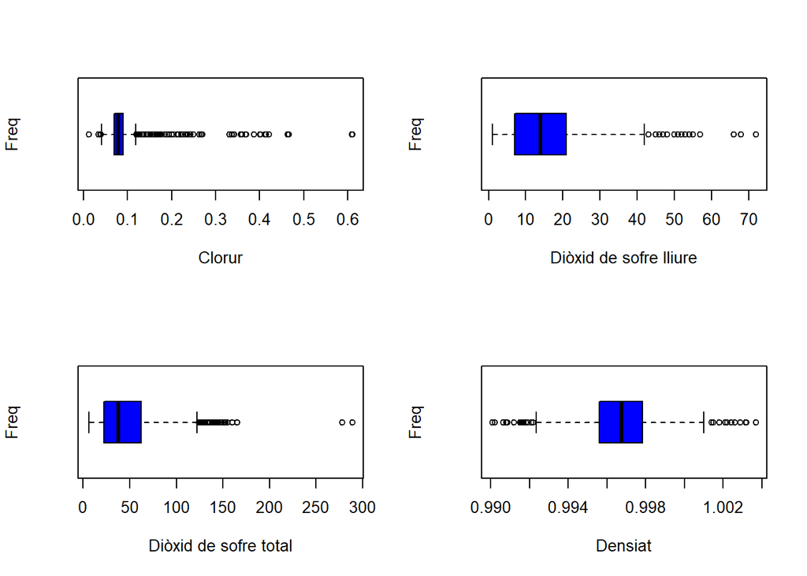

```r
boxplot(data_wine$chlorides, xlab="Clorur", col="blue", horizontal = TRUE, ylab = "Freq")
boxplot(data_wine$free.sulfur.dioxide, xlab="Diòxid de sofre lliure", col="blue", horizontal=TRUE, ylab="Freq")
boxplot(data_wine$total.sulfur.dioxide, xlab="Diòxid de sofre total", col="blue", horizontal=TRUE, ylab="Freq")
boxplot(data_wine$density, xlab="Densiat", col="blue", horizontal = TRUE, ylab = "Freq")
```

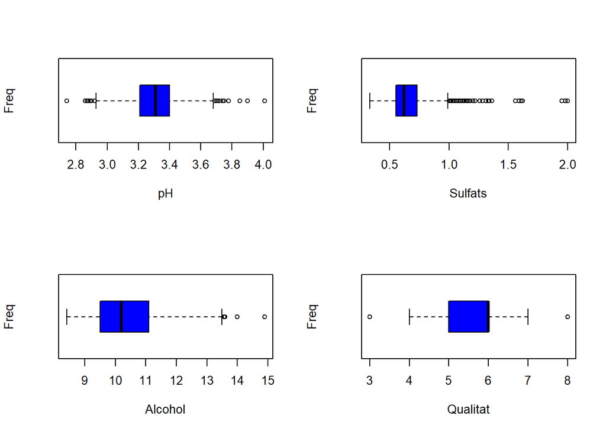

```r
boxplot(data_wine$pH, xlab="pH" ,col="blue", horizontal = TRUE, ylab = "Freq")
boxplot(data_wine$sulphates, xlab="Sulfats", col="blue", horizontal = TRUE, ylab = "Freq")
boxplot(data_wine$alcohol, xlab="Alcohol", col="blue", horizontal = TRUE, ylab = "Freq")
boxplot(data_wine$quality, xlab="Qualitat", col="blue", horizontal = TRUE, ylab = "Freq")
```

Analitzem de forma detallada les variables més representatives a l’hora de valorar la qualitat del vi. Podem visualitzar de forma més clara els valors atípics si utilitzem la funció Boxplot.Stats. Presentem els casos per a l’acidesa cítrica, el sulfat i l’alcohol.

**Acidesa cítrica**

```r
summary(data_wine$citric.acid)
```

```
##    Min. 1st Qu.  Median    Mean 3rd Qu.    Max.
##   0.000   0.090   0.260   0.271   0.420   1.000
```

```r
boxplot.stats(data_wine$citric.acid)$out
```

```
## [1] 1
```

Analitzem de forma detallada les variables més representatives a l’hora de valorar la qualitat del vi. Podem visualitzar de forma més clara els valors atípics si utilitzem la funció Boxplot.Stats.

**sulfat**

El valors extrem màxim dels sulfats és 2. Aquesta variable s’utilitza com a conservant i antioxidant.

```r
summary(data_wine$sulphates)
```

```
##    Min. 1st Qu.  Median    Mean 3rd Qu.    Max.
##  0.3300  0.5500  0.6200  0.6581  0.7300  2.0000
```

```r
boxplot.stats(data_wine$sulphates)$out
```

```
##  [1] 1.56 1.28 1.08 1.20 1.12 1.28 1.14 1.95 1.22 1.95 1.98 1.31 2.00 1.08 1.59
## [16] 1.02 1.03 1.61 1.09 1.26 1.08 1.00 1.36 1.18 1.13 1.04 1.11 1.13 1.07 1.06
## [31] 1.06 1.05 1.06 1.04 1.05 1.02 1.14 1.02 1.36 1.36 1.05 1.17 1.62 1.06 1.18
## [46] 1.07 1.34 1.16 1.10 1.15 1.17 1.17 1.33 1.18 1.17 1.03 1.17 1.10 1.01
```

**pH**

```r
summary(data_wine$pH)
```

```
##    Min. 1st Qu.  Median    Mean 3rd Qu.    Max.
##   2.740   3.210   3.310   3.311   3.400   4.010
```

```r
boxplot.stats(data_wine$pH)$out
```

```
##  [1] 3.90 3.75 3.85 2.74 3.69 3.69 2.88 2.86 3.74 2.92 2.92 2.92 3.72 2.87 2.89
## [16] 2.89 2.92 3.90 3.71 3.69 3.69 3.71 3.71 2.89 2.89 3.78 3.70 3.78 4.01 2.90
## [31] 4.01 3.71 2.88 3.72 3.72
```

**Alcohol**

```r
summary(data_wine$alcohol)
```

```
##    Min. 1st Qu.  Median    Mean 3rd Qu.    Max.
##    8.40    9.50   10.20   10.42   11.10   14.90
```

```r
boxplot.stats(data_wine$alcohol)$out
```

```
##  [1] 14.00000 14.00000 14.00000 14.00000 14.90000 14.00000 13.60000 13.60000
##  [9] 13.60000 14.00000 14.00000 13.56667 13.60000
```

### 4. Anàlisi de dades

#### 4.1. Selecció dels grups de dades que es volen analitzar/comparar

Seleccionem la qualitat del vi envers la graduació de l’alcohol

```r
vi_qualitat_alta <- data_wine$alcohol[data_wine$quality >= 7]
vi_qualitat_baixa <- data_wine$alcohol[data_wine$quality < 7]
```

#### 4.2. Comprovació de la normalitat i homogeneïtat de la variància.

**Comprovació de la normalitat**

```r
variables <- colnames(data_wine)[1:11]

par(mfrow = c(2,2))

for(variable in variables){
  print(paste0("Nom de la variable: ", variable))
  print(paste0("P-valor: ", shapiro.test(data_wine[,variable])$p.value))
}
```

```
## [1] "Nom de la variable: fixed.acidity"
## [1] "P-valor: 1.52501179295091e-24"
## [1] "Nom de la variable: volatile.acidity"
## [1] "P-valor: 2.69293489456032e-16"
## [1] "Nom de la variable: citric.acid"
## [1] "P-valor: 1.02193162131975e-21"
## [1] "Nom de la variable: residual.sugar"
## [1] "P-valor: 1.02016171149076e-52"
## [1] "Nom de la variable: chlorides"
## [1] "P-valor: 1.17905575371677e-55"
## [1] "Nom de la variable: free.sulfur.dioxide"
## [1] "P-valor: 7.69459692029225e-31"
## [1] "Nom de la variable: total.sulfur.dioxide"
## [1] "P-valor: 3.57345139578549e-34"
## [1] "Nom de la variable: density"
## [1] "P-valor: 1.93605282884883e-08"
## [1] "Nom de la variable: pH"
## [1] "P-valor: 1.71223728301906e-06"
## [1] "Nom de la variable: sulphates"
## [1] "P-valor: 5.82314039765996e-38"
## [1] "Nom de la variable: alcohol"
## [1] "P-valor: 6.64405672007326e-27"
```

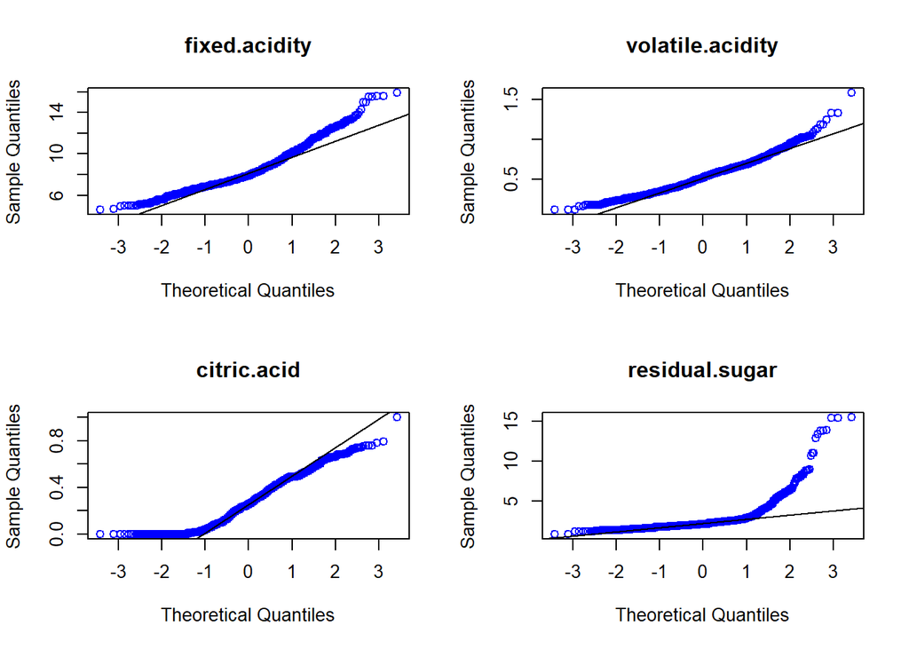

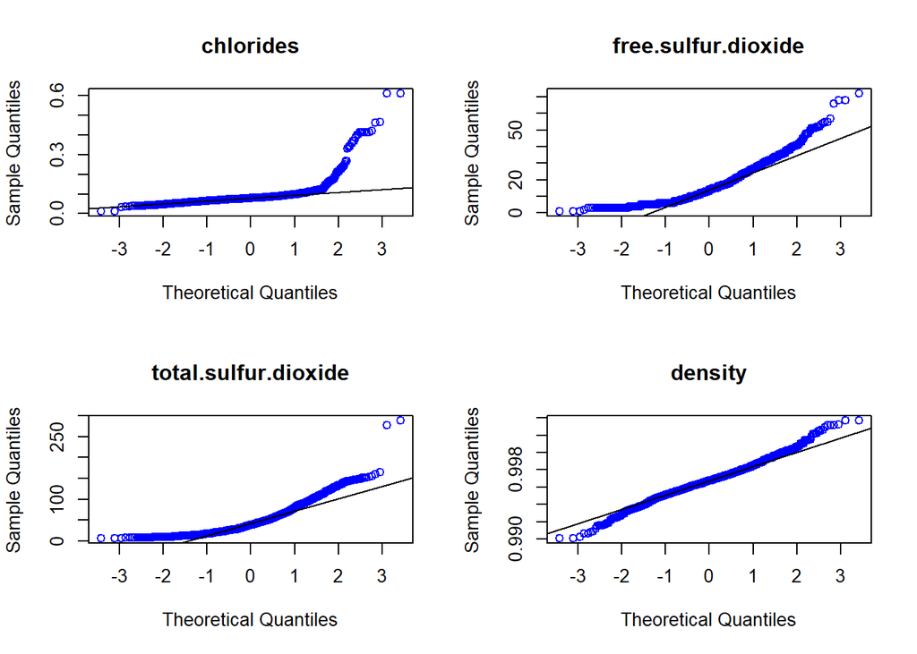

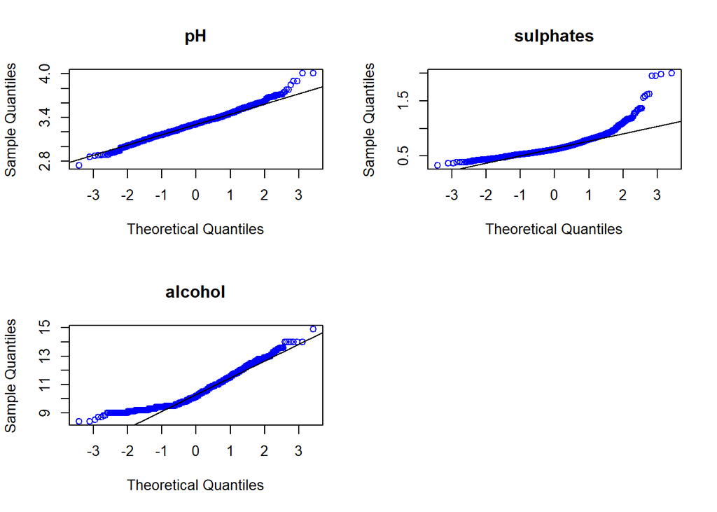

```r
for(variable in variables){
  qqnorm(data_wine[,variable], main = paste0(variable), col = "blue")
  qqline(data_wine[,variable])
}
```

**homogeneïtat de la variància**

Per comprovar l’homogeneïtat de la variància entre dues mostres, aplicarem la funció que ve donada en R var.test

```r
var.test(x = vi_qualitat_alta, y = vi_qualitat_baixa)
```

```
##
##  F test to compare two variances
##
## data:  vi_qualitat_alta and vi_qualitat_baixa
## F = 1.0596, num df = 216, denom df = 1381, p-value = 0.5562
## alternative hypothesis: true ratio of variances is not equal to 1
## 95 percent confidence interval:
##  0.8713587 1.3083664
## sample estimates:
## ratio of variances
##           1.059625
```

Podem observar que el ratio of variances té el valor 1,059625 i cau dintre de l’interval de confiança del 95% (rang entre 0,871 i 1,3083). També es pot observar que el p-value té el valor 0,5562 i és més gran de 0,05, per tant, no hi ha diferència significativa entre les variàncies dels dos grups.

#### 4.3. Aplicació de proves estadístiques per comparar els grups de dades. correlacions, regressions, etc. Aplicar almenys tres mètodes d’anàlisi diferents.

**contrast d’hipòtesis**

```r
# t de Student
t.test(vi_qualitat_alta, vi_qualitat_baixa, # les dos mostres
       alternative = "greater",  # contrast per resta de mitjanes
       paired = FALSE,  # mostres independents
       var.equal = TRUE, #
       conf.level = 0.95)
```

```
##
##  Two Sample t-test
##
## data:  vi_qualitat_alta and vi_qualitat_baixa
## t = 17.823, df = 1597, p-value < 2.2e-16
## alternative hypothesis: true difference in means is greater than 0
## 95 percent confidence interval:
##  1.150012      Inf
## sample estimates:
## mean of x mean of y
##  11.51805  10.25104
```

El resultat del contrast d’hipòtesis dóna un p-valor més petit que 0.05, que és el nivell d’acceptació, i també veiem que no cau dintre de l’interval d’acceptació de la hipòtesi nul·la, llavors ens porta a rebutjar la hipòtesi nul·la, per tant, acceptem la hipòtesi alternativa i podem dir que els vins de bona qualitat tenen en mitjana una graduació superior que els vins de més baixa qualitat.

**Correlacions**

Per calcular les correlacions entre les variables utilitzem la funció anomenada cor(), i ho representem de forma gràfica amb la funció corrplot().

```r
rcor <- cor(data_wine, use="pairwise.complete.obs", method = "pearson")
rcor
```

```
##                      fixed.acidity volatile.acidity citric.acid residual.sugar
## fixed.acidity           1.00000000     -0.256130895  0.67170343    0.114776724
## volatile.acidity       -0.25613089      1.000000000 -0.55249568    0.001917882
## citric.acid             0.67170343     -0.552495685  1.00000000    0.143577162
## residual.sugar          0.11477672      0.001917882  0.14357716    1.000000000
## chlorides               0.09370519      0.061297772  0.20382291    0.055609535
## free.sulfur.dioxide    -0.15379419     -0.010503827 -0.06097813    0.187048995
## total.sulfur.dioxide   -0.11318144      0.076470005  0.03553302    0.203027882
## density                 0.66804729      0.022026232  0.36494718    0.355283371
## pH                     -0.68297819      0.234937294 -0.54190414   -0.085652422
## sulphates               0.18300566     -0.260986685  0.31277004    0.005527121
## alcohol                -0.06166827     -0.202288027  0.10990325    0.042075437
## quality                 0.12405165     -0.390557780  0.22637251    0.013731637
##                         chlorides free.sulfur.dioxide total.sulfur.dioxide
## fixed.acidity         0.093705186        -0.153794193          -0.11318144
## volatile.acidity      0.061297772        -0.010503827           0.07647000
## citric.acid           0.203822914        -0.060978129           0.03553302
## residual.sugar        0.055609535         0.187048995           0.20302788
## chlorides             1.000000000         0.005562147           0.04740047
## free.sulfur.dioxide   0.005562147         1.000000000           0.66766645
## total.sulfur.dioxide  0.047400468         0.667666450           1.00000000
## density               0.200632327        -0.021945831           0.07126948
## pH                   -0.265026131         0.070377499          -0.06649456
## sulphates             0.371260481         0.051657572           0.04294684
## alcohol              -0.221140545        -0.069408354          -0.20565394
## quality              -0.128906560        -0.050656057          -0.18510029
##                          density          pH    sulphates     alcohol
## fixed.acidity         0.66804729 -0.68297819  0.183005664 -0.06166827
## volatile.acidity      0.02202623  0.23493729 -0.260986685 -0.20228803
## citric.acid           0.36494718 -0.54190414  0.312770044  0.10990325
## residual.sugar        0.35528337 -0.08565242  0.005527121  0.04207544
## chlorides             0.20063233 -0.26502613  0.371260481 -0.22114054
## free.sulfur.dioxide  -0.02194583  0.07037750  0.051657572 -0.06940835
## total.sulfur.dioxide  0.07126948 -0.06649456  0.042946836 -0.20565394
## density               1.00000000 -0.34169933  0.148506412 -0.49617977
## pH                   -0.34169933  1.00000000 -0.196647602  0.20563251
## sulphates             0.14850641 -0.19664760  1.000000000  0.09359475
## alcohol              -0.49617977  0.20563251  0.093594750  1.00000000
## quality              -0.17491923 -0.05773139  0.251397079  0.47616632
##                          quality
## fixed.acidity         0.12405165
## volatile.acidity     -0.39055778
## citric.acid           0.22637251
## residual.sugar        0.01373164
## chlorides            -0.12890656
## free.sulfur.dioxide  -0.05065606
## total.sulfur.dioxide -0.18510029
## density              -0.17491923
## pH                   -0.05773139
## sulphates             0.25139708
## alcohol               0.47616632
## quality               1.00000000
```

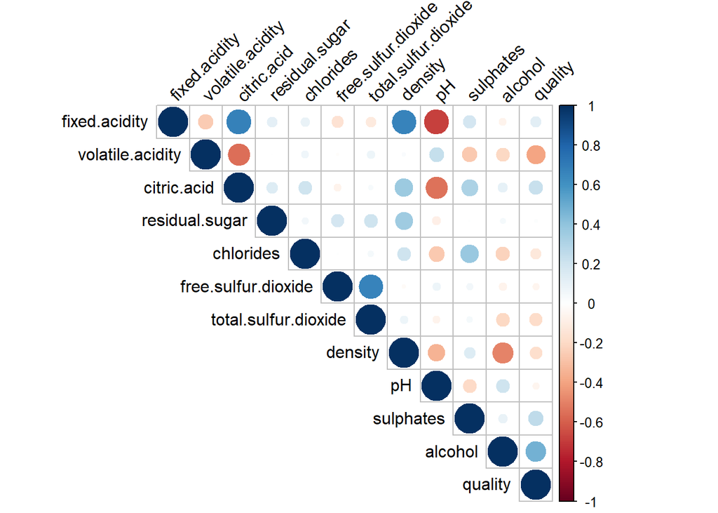

```r
corrplot(rcor, type = "upper", tl.col = "black", method = "circle", tl.srt = 45)
```

En el gràfic de correlacions resultant, els cercles més grans i de més intensitat ens indiquen un grau de correlació més alt entre les dues variables i els més petits i de menys intensitat un grau de correlació més baix.

Es pot observar en aquest gràfic que la correlació més gran que hi ha en referència a la variable Quality és amb les variables alcohol i acidesa volàtil.

**Regression linial Múltiple**

```r
rl1 <- lm(quality ~ alcohol, data = data_wine)
rl2 <- lm(quality ~ alcohol + volatile.acidity, data = data_wine)
rl3 <- lm(quality ~ alcohol + volatile.acidity + citric.acid, data = data_wine)
rl4 <- lm(quality ~ alcohol + volatile.acidity + citric.acid + pH, data = data_wine)
rl5 <- lm(quality ~ alcohol + volatile.acidity + citric.acid + pH + sulphates, data = data_wine)
```

Pels models de regressió lineal múltiple obtinguts, podem utilitzar el coeficient de determinació per a mesurar la bondat dels ajustos i quedar-nos amb aquell model que millor coeficient presenta.

```r
# Taula dels coeficients de determinació de cada model de regressió
coeficients <- matrix(c(1, summary(rl1)$r.squared,
                               2, summary(rl2)$r.squared,
                               3, summary(rl3)$r.squared,
                               4, summary(rl4)$r.squared,
                               5, summary(rl5)$r.squared),
                      ncol = 2, byrow = TRUE)

colnames(coeficients) <- c("model regresió lineal", "Coeficient de determinació")
coeficients
```

```
##      model regresió lineal Coeficient de determinació
## [1,]                     1                  0.2267344
## [2,]                     2                  0.3170024
## [3,]                     3                  0.3171882
## [4,]                     4                  0.3236633
## [5,]                     5                  0.3413432
```

**Random Forest**

```r
# Agrupem la qualitat dels vins a una nova variable
data_wine$nivell.qualitat <- ifelse(data_wine$quality < 5, "Dolent", "Bo")
data_wine$nivell.qualitat[data_wine$quality == 5 | data_wine$quality == 6] <- "Normal"
data_wine$nivell.qualitat <- as.factor(data_wine$nivell.qualitat)

# Convertim en factor la variable creada
data_wine$nivell.qualitat <- as.factor(data_wine$nivell.qualitat)

# Seed inicialitza el generador de nombres aleatoris que utilitzarem per separar les dades en train i test.
# Utilitzant un seed fixe, ens assegurem de generar el mateix conjunt de dades i els resultats són reproduïbles
set.seed(1234)

# Dividim el dataframe en 70% entrenament i 30% validació
index <- sample(2, nrow(data_wine), replace=TRUE, prob=c(0.7, 0.3))
train_data_wine <- data_wine[index==1,]
test_data_wine <- data_wine[index==2,]
```

Seguidament, utilitzem el mètode supervisat de classificació randomForest que a partir dels resultats obtinguts mitjançant el càlcul de n arbres, construeix el resultat de l’estimació que volem obtenir.

```r
set.seed(12)

#Declarem la funció de l'arbre
ArbrelRF <- nivell.qualitat ~ alcohol + volatile.acidity + citric.acid + pH + sulphates

# #Apliquem l'algoritme
model_random_forest <- randomForest(ArbrelRF, data = train_data_wine, ntree=100, proximity= T, nodesize=5) #indiquem el nombre d'arbres mitjançant ntree = 500

# #Obtenim la importancia de cada variable en el procés de clasificació
importance(model_random_forest)      #Importancia de las variables en formato text
```

```
##                  MeanDecreaseGini
## alcohol                  73.61480
## volatile.acidity         60.50129
## citric.acid              46.63158
## pH                       38.84138
## sulphates                51.83553
```

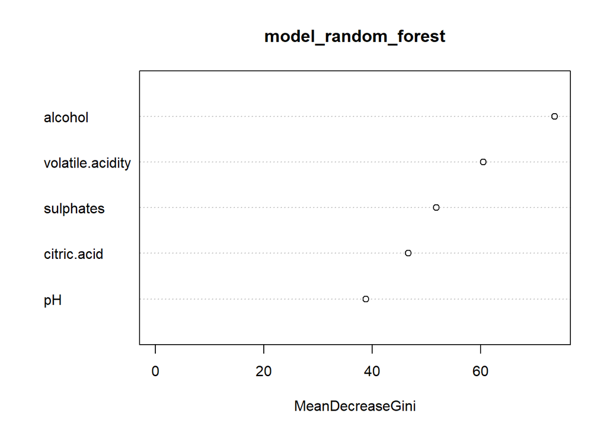

```r
varImpPlot(model_random_forest) #Importancia de las variables en formato gráfico
```

```r
# Validem la capacitat de predicció de l'arbre amb el fitxer de validació.
preds_random_forest <- predict(model_random_forest, newdata = test_data_wine)
table(preds_random_forest, test_data_wine$nivell.qualitat)
```

```
##
## preds_random_forest  Bo Dolent Normal
##              Bo      27      0     13
##              Dolent   0      1      0
##              Normal  33     18    366
```

```r
# Calculem el % d'encerts
sum(preds_random_forest == test_data_wine$nivell.qualitat)/ length(test_data_wine$nivell.qualitat) * 100
```

```
## [1] 86.0262
```

L’arbre de decisió obtingut mitjançant el paquet randomForest classifica correctament un 86,02% dels registres. Un resultat no massa alt però acceptable.

**Arbre de decisió**

Per a construir un arbre de decisions és necessari definir una funció que relacioni una variable categòrica dependent (factor) amb n variables que poden ser categòriques o numèriques. En el nostre cas treballarem amb:

1 variable factor dependent -> nivell.qualitat

5 variables independents -> alcohol, volatile.acidity, citric.acid, pH, sulphates

L’algoritme de classificació busca quina és la variable que permet obtenir una submostra més diferenciada per la variable dependent (nivell.qualitat), i identificar també quins intervals (si la variable és quantitativa) o agrupació de categories de les variables independents permetran maximitzar aquesta divisió.

Estudiem a continuació la capacitat predictiva de l’arbre de decisió simple obtingut mitjançant el paquet rpart. Utilitzarem les dades d’entrenament i test obtingudes en l’apartat del model Random Forest.

```r
# Declarem la funció de l'arbre
ArbreRpart = nivell.qualitat ~ alcohol + volatile.acidity + citric.acid + pH + sulphates
#Apliquem l'algoritme
model_tree = rpart(ArbreRpart, method="class", data=train_data_wine)
# Validem la capacitat de predicció de l'arbre amb el fitxer de validació
preds_tree <- predict(model_tree, newdata = test_data_wine, type = "class")
# Visualitzem una matriu de confusió
table(preds_tree, test_data_wine$nivell.qualitat)
```

```
##
## preds_tree  Bo Dolent Normal
##     Bo      28      0     16
##     Dolent   0      0      0
##     Normal  32     19    363
```

```r
# Calcula el % d'encerts
sum(preds_tree == test_data_wine$nivell.qualitat)/ length(test_data_wine$nivell.qualitat)*100
```

```
## [1] 85.37118
```

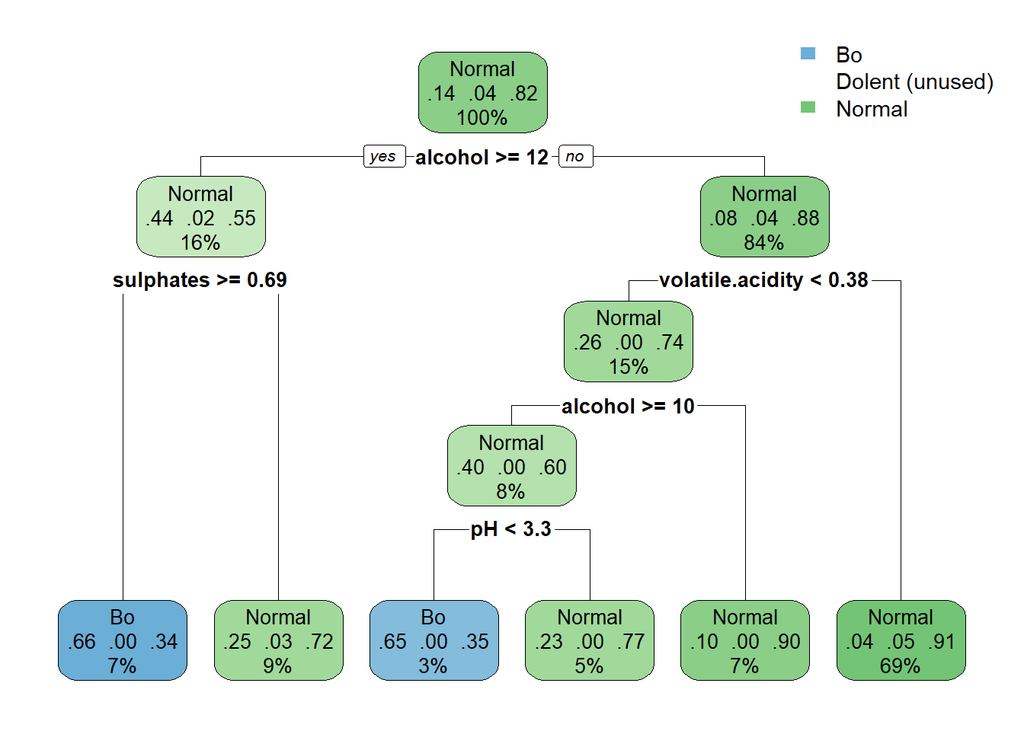

```r
rpart.plot(model_tree)
```

### 5. Representació dels resultats a partir de taules i gràfiques

**Arbre de decisions**

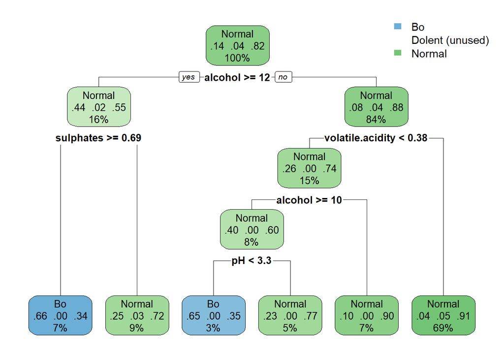

```r
rpart.plot(model_tree)
```

**Gràfiques**

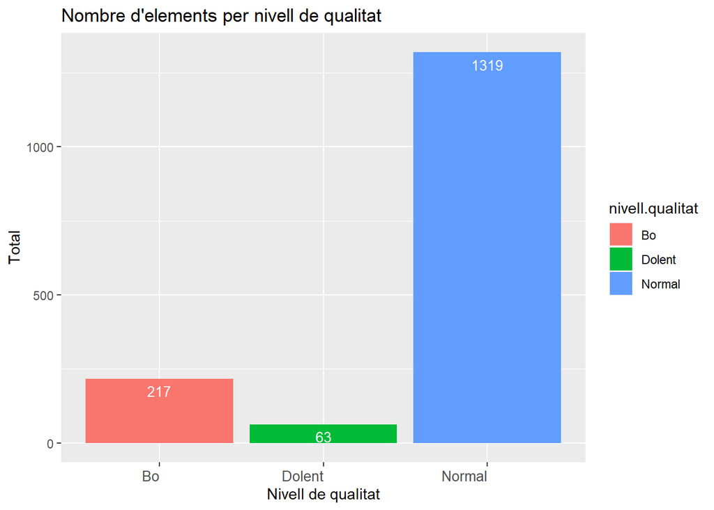

```r
n_nivell.qualitat <- dplyr::count(data_wine, nivell.qualitat)

ggplot(data = n_nivell.qualitat, aes(nivell.qualitat , n, fill = nivell.qualitat)) +
  geom_bar(stat="identity") +
  geom_text(aes(label=n), vjust=1.6, color="white",position = position_dodge(0.9), size=3.5) +
  xlab("Nivell de qualitat") + ylab("Total") + ggtitle("Nombre d'elements per nivell de qualitat") +
  theme(axis.text.x = element_text(angle = 0, size = 10, hjust = 1, vjust = 1))
```

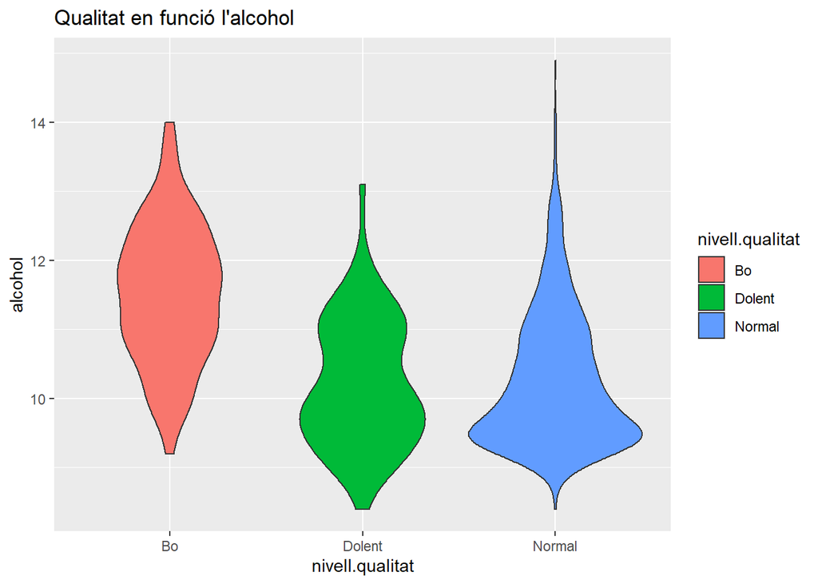

```r
ggplot(data_wine, aes(x=nivell.qualitat, y=alcohol, fill=nivell.qualitat)) +
  ggtitle("Qualitat en funció l'alcohol") +
  geom_violin()
```

Segons els experts, el grau d’alcohol no és un condicionant de la qualitat del vi, no obstant això, en aquesta ocasió podem veure que els vins de qualitat alta tendeixen a tenir un grau d’alcohol major, però estan distribuïts en un rang aproximadament entre 9º i 14º.

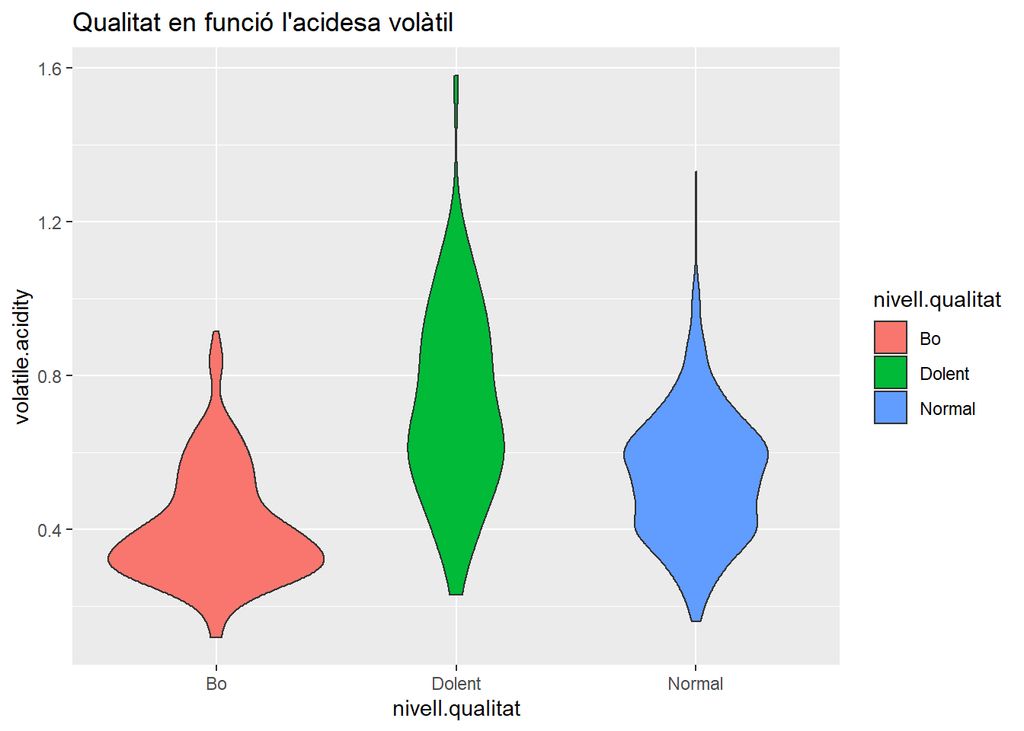

```r
ggplot(data_wine, aes(x=nivell.qualitat, y=volatile.acidity, fill=nivell.qualitat)) +
  ggtitle("Qualitat en funció l'acidesa volàtil") +
  geom_violin()
```

L’acidesa volàtil afecta el sabor del vi, per aquest motiu és important que el seu valor sigui baix. Podem veure que els vins de qualitat més alta (Bo) tendeixen a tenir una acidesa volàtil més baixa.

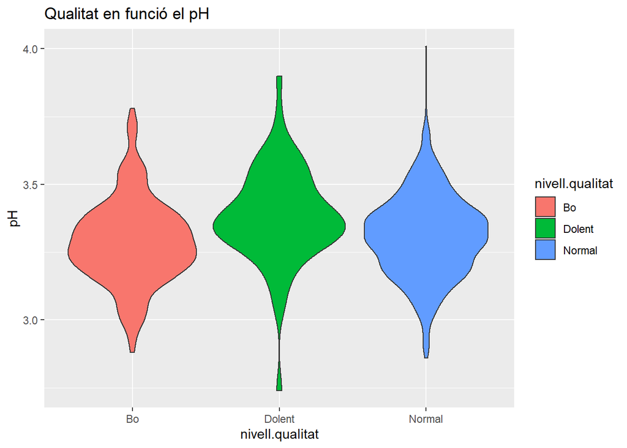

```r
ggplot(data_wine, aes(x=nivell.qualitat, y=pH, fill=nivell.qualitat)) +
  ggtitle("Qualitat en funció el pH") +
  geom_violin()
```

En aquest gràfic podem veure com els vins etiquetats com a Bo tendeixen a presentar més dades al voltant del valor de pH 3,25.

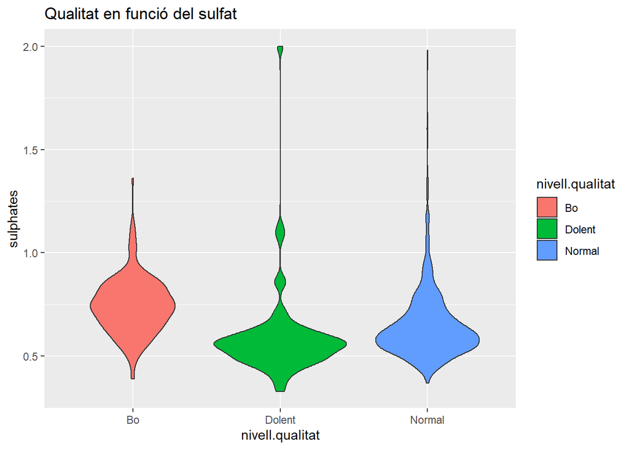

```r
ggplot(data_wine, aes(x=nivell.qualitat, y=sulphates, fill=nivell.qualitat)) +
  ggtitle("Qualitat en funció del sulfat") +
  geom_violin()
```

Els vins de qualitat més bona, en general presenten una quantitat de sulfat més gran que els vins de menys qualitat. Aquest element s’utilitza com a conservant i antioxidant.

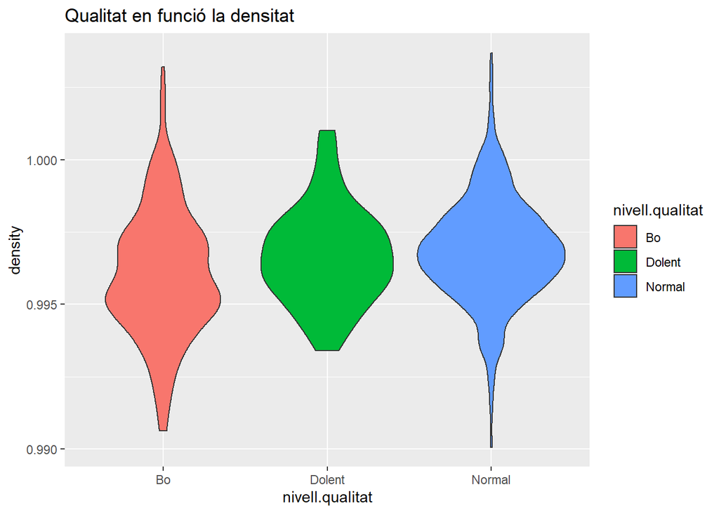

```r
ggplot(data_wine, aes(x=nivell.qualitat, y=density, fill=nivell.qualitat)) +
  ggtitle("Qualitat en funció la densitat") +
  geom_violin()
```

Els vins etiquetats com a bons presenten una densitat més baixa que els etiquetats com a dolents o normal.

### 7. Codi.

```r
data_wine_result <- dplyr::select(data_wine,
                                  volatile.acidity,
                                  citric.acid,
                                  alcohol,
                                  pH,
                                  sulphates,
                                  quality,
                                  nivell.qualitat)


write.csv(data_wine_result, "winequality-red_result.csv", row.names = FALSE)
```